# Discussion 5

Jaideep Bollu

1. Use the built-in data set called `faithful`, see the Help file for the description of this data set. Create a histogram for the `eruptions` variable. Adjust the axis labels and title to make the graph professional looking. (1 pt)

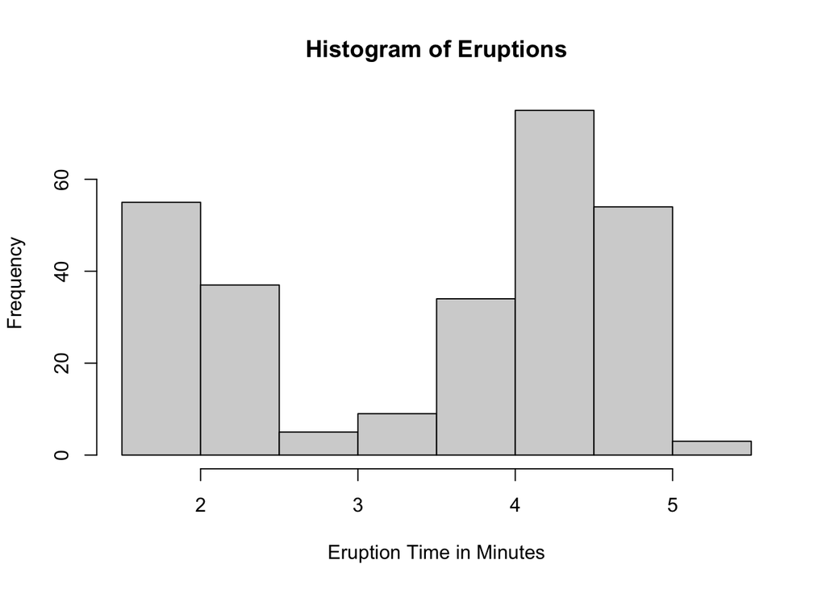

```r
help("faithful")
hist(faithful$eruptions,  main = "Histogram of Eruptions", ylab = "Frequency", xlab = "Eruption Time in Minutes")
```

2. Create a histogram for the `waiting` column of the `faithful` data set. Use at least 4 arguments for this function that you find in the help file. Make sure at least two of these arguments are not: `main`, `xlab`, `ylab`, `col`, `breaks`. The other remaining arguments are not limited. (1 pt)

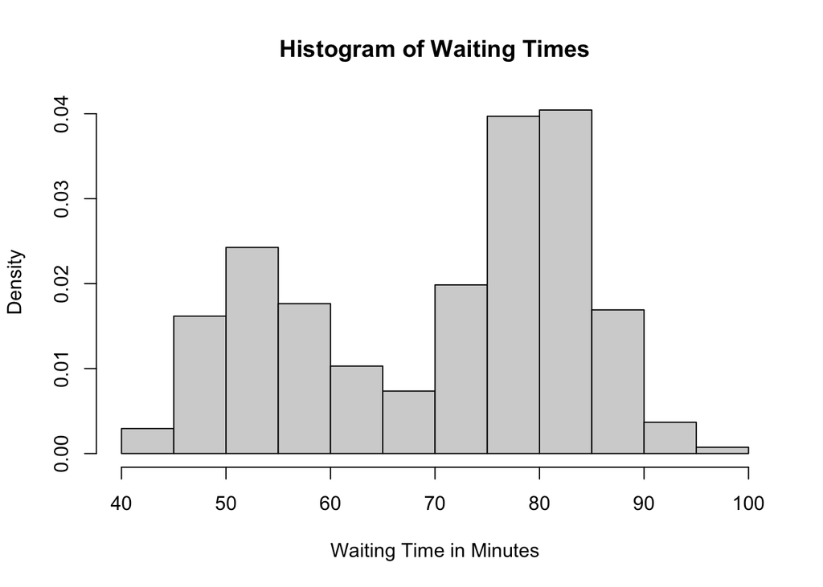

```r
hist(faithful$waiting, main = "Histogram of Waiting Times", xlab = "Waiting Time in Minutes", ylab = "Density", freq = FALSE, right = TRUE)
```

3. Create a function called `extreme.temp()`. In this function we will check if the inputted temperature is extreme. Make this function have two arguments. Let the first argument be named `tempType`, and the second argument called `temp`. If `tempType="F"` then the `temp` is in Fahrenheit units, and if `tempType="C"` then `temp` is in Celsius units. Return a character vector of length one called `status` which indicates if the inputted `temp` is “boiling”, “freezing”, or “good”. You may use/call functions created last week. (2 pts)

```r
extreme.temp <- function(tempType, temp) {
  if (tempType == "F") {
    if (temp >= 212) {
      status <- c("boiling")
    }

    else if (temp <= 32) {
      status <- c("freezing")
    }

    else {
      status <- c("good")
    }
  }

  else if (tempType == "C") {
    if (temp >= 100) {
      status <- c("boiling")
    }

    else if (temp <= 0) {
      status <- c("freezing")
    }

    else {
      status <- c("good")
    }
  }

  else {
    stop("Wrong Unit")
  }

  return(status)
}
```

4. Using the `sapply()` function, check the temperatures 20C, -13C, 70C, and 150C for the function you created in Q3. (1 pt)

```r
temp <- c(20, -13, 70, 150)

sapply(temp, function(t) extreme.temp("C", t))
```

```
## [1] "good"     "freezing" "good"     "boiling"
```

5. Create the function which has one argument `n`. Have this function generate the first n Fibannaci numbers using a **while** loop. Note that the Fibanacci sequence is formed by starting with the number 0, 1 and then adding the last two numbers to get the next number: 0, 1, 1, 2, 3, 5, 8, etc. (2 pts)

```r
fibbonacci_sequence <- function(n) {
  if (n == 1) {
    print(c(0))
  }

  else if (n == 2) {
    print(c(0, 1))
  }

  else {
    x <- c(0, 1)
    i <- 0
    while (i <= (n - 2)) {
      x <- append(x, (x[i] + x[i + 1]))
      i <- i + 1
    }
    return(x)
  }
}
```

6. Call your function from Q5 using `n=8` and `n=30`. (0.5 pts)

```r
fibbonacci_sequence(8)
```

```
## [1]  0  1  1  2  3  5  8 13
```

```r
fibbonacci_sequence(30)
```

```
##  [1]      0      1      1      2      3      5      8     13     21     34
## [11]     55     89    144    233    377    610    987   1597   2584   4181
## [21]   6765  10946  17711  28657  46368  75025 121393 196418 317811 514229
```